# project1-temperature

Collin

10/26/2020

### **Project 1**

File “temperature.csv” contains average monthly temperature, say xt, of a region with humid continental climate from January 1964 until December 1975. In this problem, we are going to fit a special type of structural model,

**a)** *(a) plot the data and elaborate on the general pattern of the data.*

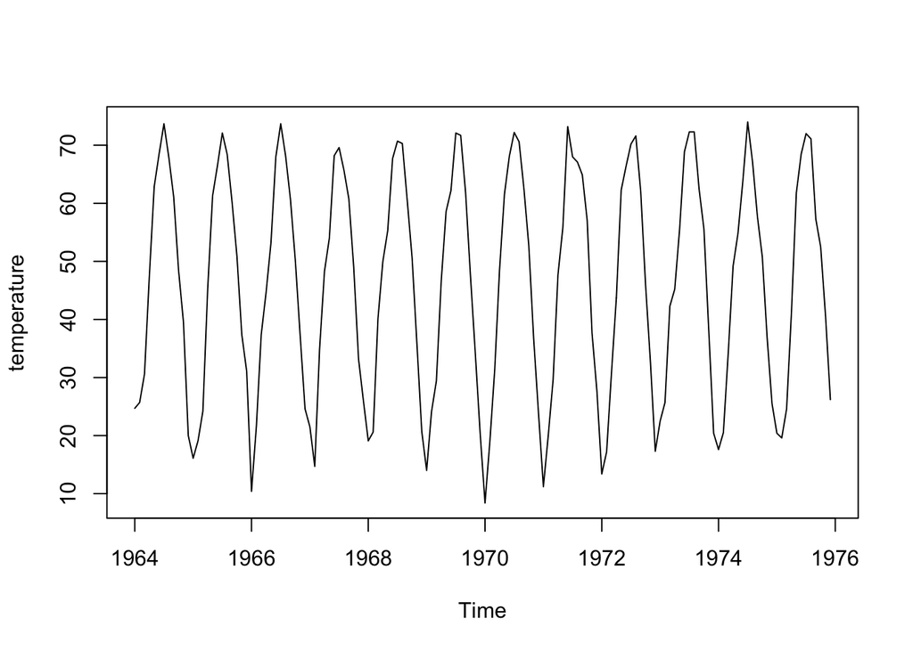

```r
temperature <- read.csv("~/Google Drive/UC Davis/UC Davis/fall_quarter_2020/STA137-Time_Series/temperature.csv", sep="")
month = factor(cycle(temperature$temperature),12) #create the seasonal component


myts <- ts(temperature, start=c(1964, 1), end=c(1975, 12), frequency=12)


#a
plot(myts)
```

The main thing worth mentioning is that there is clearly a seasonal component to this temperature time series!

**b** *Fit the regression model:*

```r
fit = lm(temperature ~ 0 + factor(cycle(myts)),data = myts,na.action = NULL) #no intercept by including 0
summary(fit)
```

```
##
## Call:
## lm(formula = temperature ~ 0 + factor(cycle(myts)), data = myts,
##     na.action = NULL)
##
## Residuals:
##     Min      1Q  Median      3Q     Max
## -8.2750 -2.2479  0.1125  1.8896  9.8250
##
## Coefficients:
##                       Estimate Std. Error t value Pr(>|t|)
## factor(cycle(myts))1    16.608      0.987   16.83   <2e-16 ***
## factor(cycle(myts))2    20.650      0.987   20.92   <2e-16 ***
## factor(cycle(myts))3    32.475      0.987   32.90   <2e-16 ***
## factor(cycle(myts))4    46.525      0.987   47.14   <2e-16 ***
## factor(cycle(myts))5    58.092      0.987   58.86   <2e-16 ***
## factor(cycle(myts))6    67.500      0.987   68.39   <2e-16 ***
## factor(cycle(myts))7    71.717      0.987   72.66   <2e-16 ***
## factor(cycle(myts))8    69.333      0.987   70.25   <2e-16 ***
## factor(cycle(myts))9    61.025      0.987   61.83   <2e-16 ***
## factor(cycle(myts))10   50.975      0.987   51.65   <2e-16 ***
## factor(cycle(myts))11   36.650      0.987   37.13   <2e-16 ***
## factor(cycle(myts))12   23.642      0.987   23.95   <2e-16 ***
## ---
## Signif. codes:  0 '***' 0.001 '**' 0.01 '*' 0.05 '.' 0.1 ' ' 1
##
## Residual standard error: 3.419 on 132 degrees of freedom
## Multiple R-squared:  0.9957, Adjusted R-squared:  0.9953
## F-statistic:  2569 on 12 and 132 DF,  p-value: < 2.2e-16
```

```r
#i
janToFeb = 20.650-16.608
febToMar = 32.475-20.650
marToApr = 46.525-32.475
aprToMay = 58.092 - 46.525
mayToJun = 67.500 - 58.092
juntoJuly = 71.717-67.500
julyToAug = 69.333 - 71.717
augToSep = 61.025-69.333
sepToOct = 50.975 - 61.025
octToNov = 36.650 -50.975
novToDec = 23.642-36.650

vecOfTempChanges = c(janToFeb,febToMar,marToApr,aprToMay,mayToJun,juntoJuly,julyToAug,augToSep,sepToOct,octToNov,
  novToDec)


tempChange = matrix(vecOfTempChanges,nrow = 1,ncol=11,byrow = TRUE)
colnames(tempChange)= c('janToFeb','febToMar','marToApr','aprToMay','mayToJun','juntoJuly','julyToAug','augToSep','sepToOct','octToNov',
                        'novToDec')
tempChange
```

```
##      janToFeb febToMar marToApr aprToMay mayToJun juntoJuly julyToAug augToSep
## [1,]    4.042   11.825    14.05   11.567    9.408     4.217    -2.384   -8.308
##      sepToOct octToNov novToDec
## [1,]   -10.05  -14.325  -13.008
```

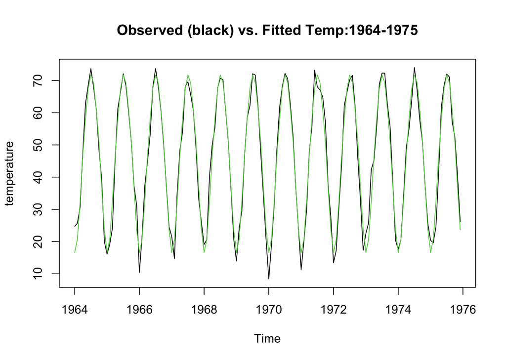

```r
#ii
fit = lm(temperature ~ 0 + factor(cycle(myts,12)),data = myts,na.action = NULL)
fittedTS = ts(fit$fitted.values,start=c(1964, 1), end=c(1975, 12), frequency=12)

plot.ts(myts, xlab = "Time",main = "Observed (black) vs. Fitted Temp:1964-1975")
par(new=TRUE)
lines(fittedTS,col=3)
```

The fitted values appear to fit the time series exceptionally well.There is significant overlap between the fitted and observed temperature values over the time series, and the residuals appear to be miniscule.

**c** *In this part we try to find dominant periodic components in the data. Fit the regression model*

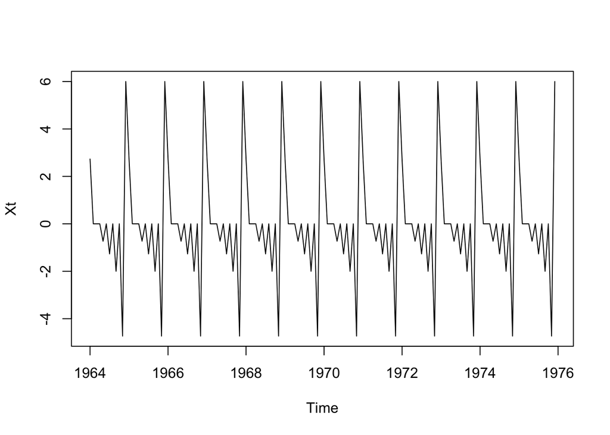

```r
#fit the model
tIndex = 1:144
someFunction = function(t){
  cos((2*pi*1*t/12)) + sin((2*pi*1*t/12)) + cos((2*pi*2*t/12)) + sin((2*pi*2*t/12)) +
    cos((2*pi*3*t/12)) + sin((2*pi*3*t/12)) + cos((2*pi*4*t/12)) + sin((2*pi*4*t/12)) +
    cos((2*pi*5*t/12)) + sin((2*pi*5*t/12)) + cos((2*pi*6*t/12)) + sin((2*pi*6*t/12))
}

reg = lm(temperature$temperature ~ cos((2*pi*1*tIndex/12)) + sin((2*pi*1*tIndex/12)) + cos((2*pi*2*tIndex/12)) + sin((2*pi*2*tIndex/12)) +
           cos((2*pi*3*tIndex/12)) + sin((2*pi*3*tIndex/12)) + cos((2*pi*4*tIndex/12)) + sin((2*pi*4*tIndex/12)) +
           cos((2*pi*5*tIndex/12)) + sin((2*pi*5*tIndex/12)) + cos((2*pi*6*tIndex/12)) + sin((2*pi*6*tIndex/12)))


#plotting this function over 1-144 looks like this
Xt = ts(someFunction(tIndex),start=c(1964, 1), end=c(1975, 12), frequency=12)
plot(Xt)
```

```r
#(i) If the model is correct, determine the significant frequencies in the time series. Based on your analysis, how many months it takes for the time series to repeat itself.

#regressing temperature on this function yields:
summary(reg)
```

```
##
## Call:
## lm(formula = temperature$temperature ~ cos((2 * pi * 1 * tIndex/12)) +
##     sin((2 * pi * 1 * tIndex/12)) + cos((2 * pi * 2 * tIndex/12)) +
##     sin((2 * pi * 2 * tIndex/12)) + cos((2 * pi * 3 * tIndex/12)) +
##     sin((2 * pi * 3 * tIndex/12)) + cos((2 * pi * 4 * tIndex/12)) +
##     sin((2 * pi * 4 * tIndex/12)) + cos((2 * pi * 5 * tIndex/12)) +
##     sin((2 * pi * 5 * tIndex/12)) + cos((2 * pi * 6 * tIndex/12)) +
##     sin((2 * pi * 6 * tIndex/12)))
##
## Residuals:
##    Min     1Q Median     3Q    Max
## -8.571 -2.319  0.112  1.928  9.661
##
## Coefficients:
##                                 Estimate Std. Error t value Pr(>|t|)
## (Intercept)                    4.624e+01  2.834e-01 163.182  < 2e-16 ***
## cos((2 * pi * 1 * tIndex/12)) -2.207e+01  4.004e-01 -55.121  < 2e-16 ***
## sin((2 * pi * 1 * tIndex/12)) -1.524e+01  4.002e-01 -38.094  < 2e-16 ***
## cos((2 * pi * 2 * tIndex/12)) -7.251e-01  4.007e-01  -1.810   0.0726 .
## sin((2 * pi * 2 * tIndex/12)) -2.026e+00  4.002e-01  -5.062 1.38e-06 ***
## cos((2 * pi * 3 * tIndex/12))  6.043e-02  4.001e-01   0.151   0.8802
## sin((2 * pi * 3 * tIndex/12)) -9.155e-01  4.018e-01  -2.278   0.0243 *
## cos((2 * pi * 4 * tIndex/12)) -8.006e-02  4.004e-01  -0.200   0.8418
## sin((2 * pi * 4 * tIndex/12))  1.667e-01  4.002e-01   0.417   0.6777
## cos((2 * pi * 5 * tIndex/12))  1.868e-01  4.078e-01   0.458   0.6477
## sin((2 * pi * 5 * tIndex/12))  6.016e-02  4.010e-01   0.150   0.8810
## cos((2 * pi * 6 * tIndex/12)) -1.065e-01  3.272e-01  -0.325   0.7455
## sin((2 * pi * 6 * tIndex/12)) -2.828e+13  1.673e+13  -1.690   0.0933 .
## ---
## Signif. codes:  0 '***' 0.001 '**' 0.01 '*' 0.05 '.' 0.1 ' ' 1
##
## Residual standard error: 3.395 on 131 degrees of freedom
## Multiple R-squared:  0.9718, Adjusted R-squared:  0.9693
## F-statistic: 376.8 on 12 and 131 DF,  p-value: < 2.2e-16
```

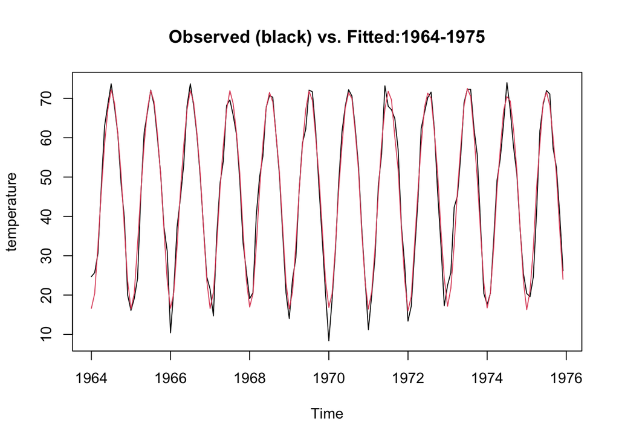

```r
#(ii)Graph the data, xt, and superimpose the fitted values, say x^t, on the graph.

fittedTS2 = ts(reg$fitted.values,start=c(1964, 1), end=c(1975, 12), frequency=12)
plot.ts(myts, xlab = "Time",main = "Observed (black) vs. Fitted:1964-1975")
par(new=TRUE)
lines(fittedTS2,col=2)
```

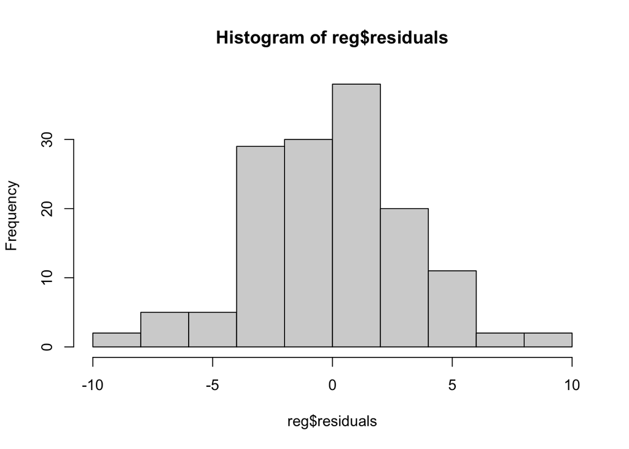

```r
#(iii) Examine the residuals, 𝑥𝑡−𝑥̂𝑡, and state your conclusions, Does it appear that the model fits the data well (do the residuals look white)? Does it appear that the residuals are a sample from a Normal distribution? Justify your answer.


hist(reg$residuals)
```

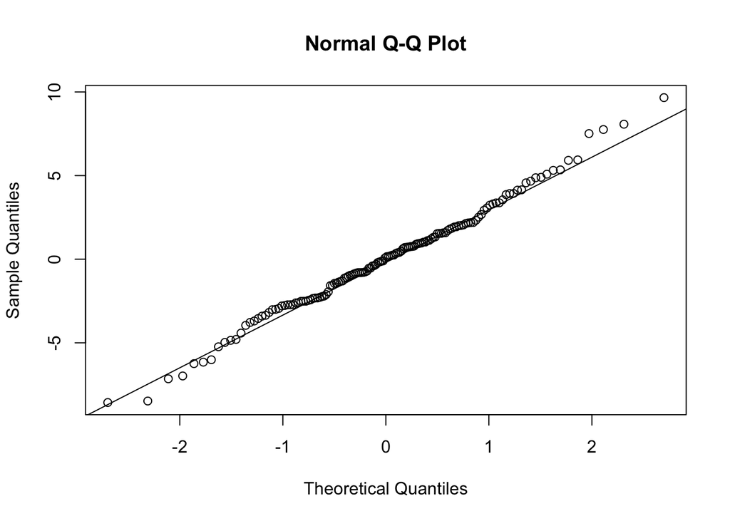

```r
qqnorm(reg$residuals)
qqline(reg$residuals)
```

based on the overlaying of the fitted values onto the actual time series, the residuals appear small, signifying that these periodic components explain much of the variation in the model of temperature.

the residuals do in fact appear to be (approximately) normally distributed. While not perfectly normal, a large proportion of the errors are centered around 0, and they disperse to the left and right in a bell shape.